# Part II - Prosper Loan Amount Key Features Visualization

## by Wilson Okah

## Investigation Overview

> I focused on the influence of the Income range, Loan term, monthly income, credit grade, credit score and the borrower's state on the Loan Amount. I start by introducing the Loan Amount variable, followed by the pattern in Monthly income distribution, then the distribution of the credit score lower range, I introduced the categorical variables like the income range, credit score levels, borrower's state and credit grade. Boxplots, violin plots and trend lines were used to show the relationship between this variables and the original loan amount. A scatter plot is used to show how the Loan Amount correlates with the Monthly loan payment. The states with the most borrowers were gotten and their average income and average loan amount was ploted to show the correlation betwwen higher income and higher loan Amount

## Dataset Overview

> The data set contains 113,937 loans with 81 variables on each loan, including loan amount, borrower rate (or interest rate), current loan status, borrower income, and many others.
> - The dataset can be found [here](https://s3.amazonaws.com/udacity-hosted-downloads/ud651/prosperLoanData.csv),
> - with feature documentation available [here](https://docs.google.com/spreadsheets/d/1gDyi_L4UvIrLTEC6Wri5nbaMmkGmLQBk-Yx3z0XDEtI/edit#gid=0).

## Distribution Of the Loan Original Amount

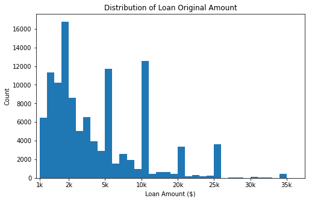

## Distribution Of the Monthly Income of borrowers

> The monthly income distribution is a Unimodal distribution that shows that most borrowers have a monthly income within the ranges of \$2500 and \\$10,000 With \$3000 dollars is the peak value

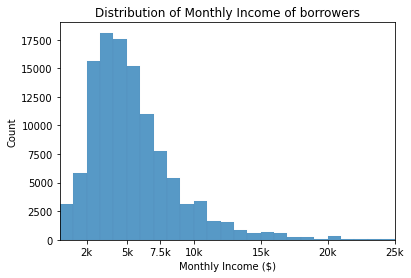

## Credit Grade

> The credit grade ranges between HR being the worst grade and AA being the best grade most borrowers have a credit grade of D,C,B with most people having the C credit grade

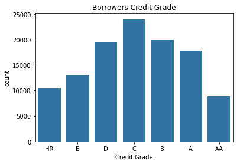

## (Credit Score and Credit Score Levels)

> The credit score lower range has a unimodal distribution with its peak value at 700. The credit Score of most borrowers fall with the value of 600 and 800. The credit score ranges were grouped innto 4 levels
> - Bad = 300-629
> - Fair = 630-679
> - Good = 680- 719
> - Excellent = 720-900

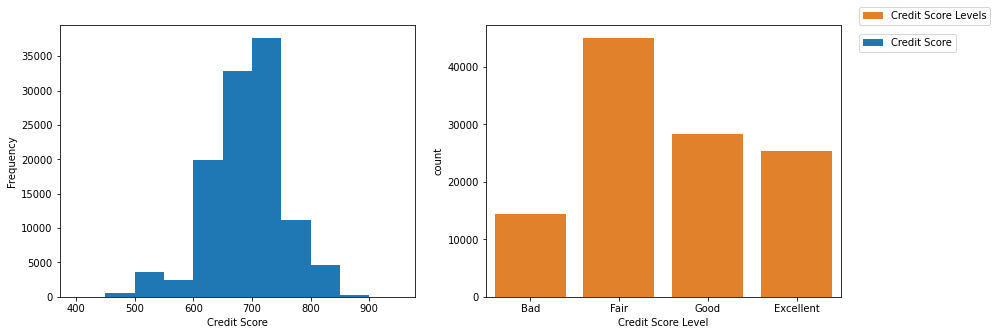

## Income Range

> Most borrowers fall within the income range of \$25,000 to \\$74,999k. with \$25,000- \\$49,999 having the highest count

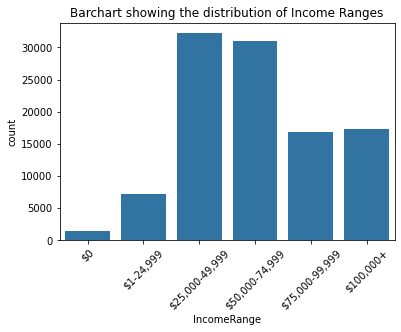

## Scatter plot of Loan amount against the Monthly loan payment

> There is a strong postive correlation between the Loan Amount and the Monthly Loan Payment. The higher the Loan collected the higher the Monthly payment this is depicted in the scatter plot

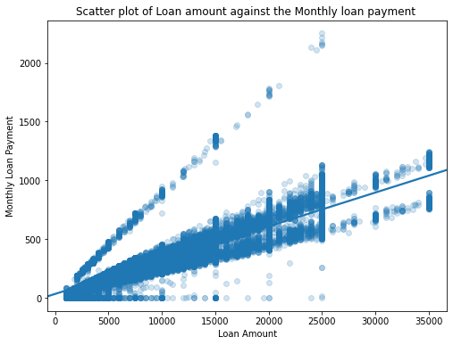

## Trend of Loan Amount And Loan Payment by Year

> There was a rise in the loan amount requested by borrowers up till 2007 then a sharp decline in the loan amount till 2009 then a steady increase in Average loan Amount between 2010 and 2014. The Payment made yearly follows a similar trend which is due to the strong correlation they have
> - The Average Loan Amount given every year is higher than the average Payment made on Loans every year.

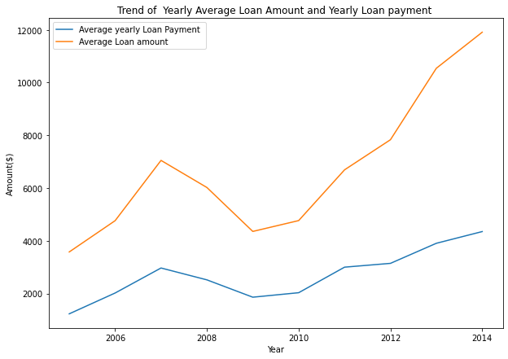

## Borrower's State and their Income Ranges

> States that have the most borrowers Like CA have a higher amount of people earning above \$25,000 than states like ND who had the least amount of borrrowers.

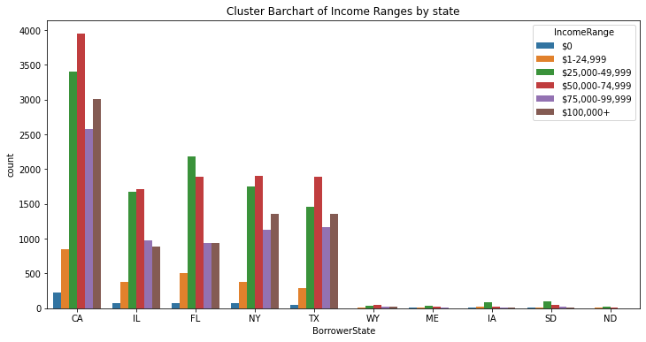

## Average Loan Amount and Average monthly income by state

> The cluster bar chart reveals how higher average income in a State leads to a higher average loan amount borrowed in that state.

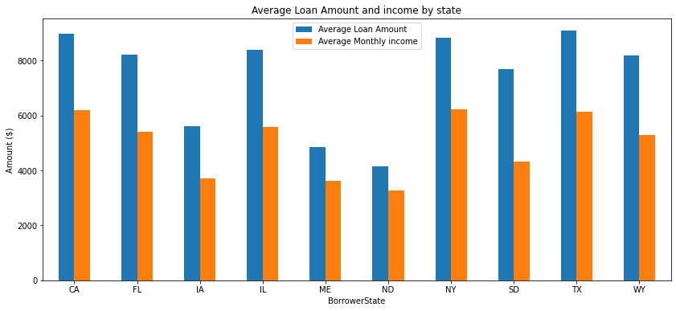

## Correlation between Averge income and Average Loan Amount of 10 states

> There is a strong positive correlation between the Income earned by borrowers and the Amount borrowed. So States with higher income would have higher Loan Amounts being borrowed

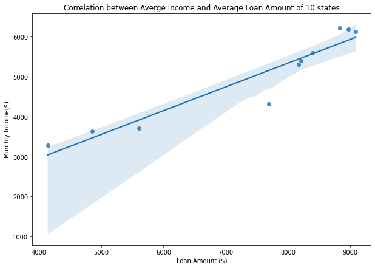

## Credit Score Levels and their respective Average Loan Amount

> There is a positive relationship betwwen your credit score level and Loan Amount you can borrow. The better the credit score level the higher the Loan Amount

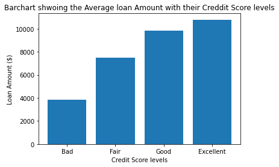

## Boxplot and ViolinPlot of the Loan Status ,Term,Credit rating,Employment Status of the Loan Amount

> There is a positive relationship between the loan term and the Loan Amount Higher Terms would mean a larger Loan Amount
> - The Credit grade has a positive relationship with Loan Amount the better your creit grade the higher the Loan Amount

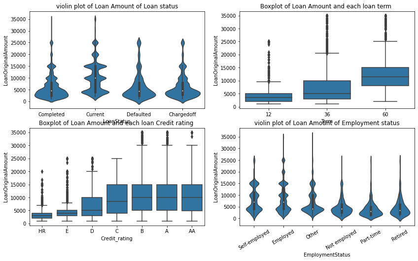

## Loan Amount vs Monthly loan payment by their employment status

> Majority of Borrowers are employed there is a linear trend between the Loan Amount and the Monthly amount paid irrespective of the borrowers employment status. So employment status has no effect on the trend as all trends display a high positive correlation

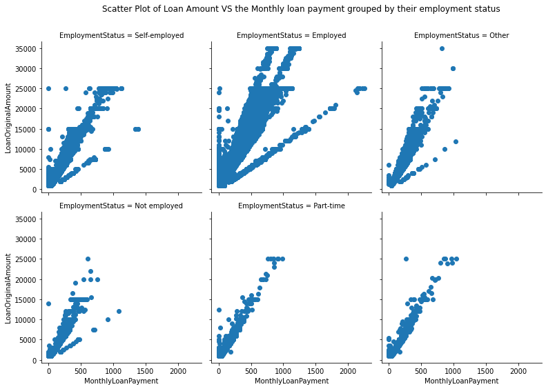

## Relationship between Employment Status and Loan Amount

> Across the 6 Employment statuses identified **Employed** status has the highest average loan amount followed by those who are self employed. But suprisingly Those who are **Not Employed** have a higher averge Loan Amount that borrowers who work part time. this is depicted in the bar chart

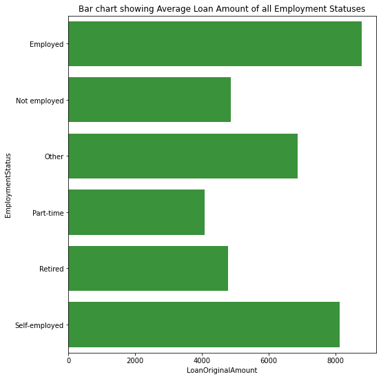

## Relationship between the Loan Term Loan Amount and the Borrower's Income Range

> There is a positive relattionship between the Loan Term and the LOan Amount , The Borrowe Income Range and the Loan Meaning . meaning a higher Term and a higher icome would lead to a higher loan Amount

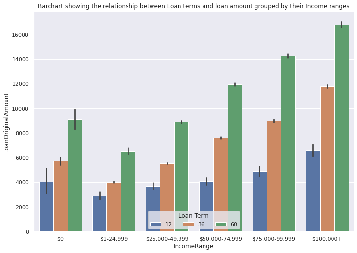

## Loan Amount of the *Five* states with the most borrowers and their income ranges

> Betwwen the income ranges of \$1 and \\$100k+ there is a similar trend across all states where an increase in uyour income range positively increases the Loan Amount with the Exception of the \$0 income range which has suprisingly high values. Your state has no effect on your loan Amount

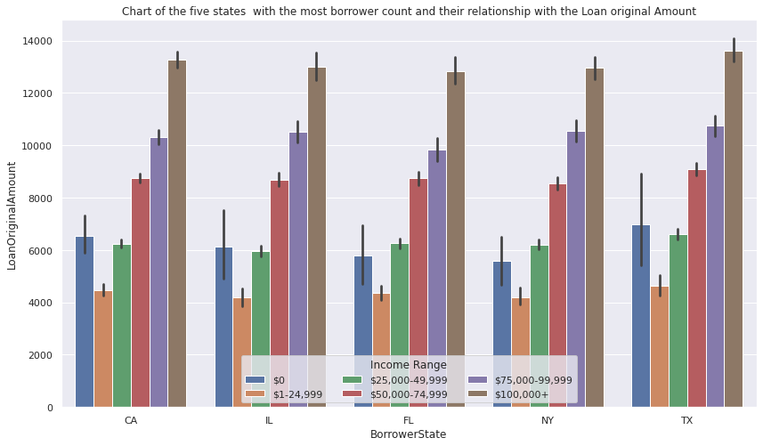

## Relationship between Occupation, Loan Amount and their Credit Score level

> The occupation of a borrower can influnece the loan Amount gotten as seen in the case of exectives. Because professsion infleunces your income range which has a positive effect on your loan Amount

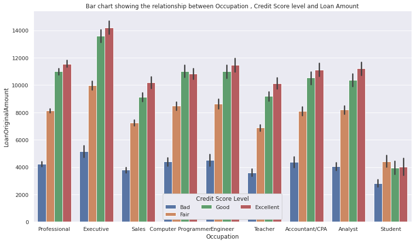